# DATA 624: PREDICTIVE ANALYTICS HW1

Gabriel Campos

Last edited February 06, 2024

```r
library('fpp3')
library('tsibble')
library('ggplot2')
library('USgas')
library('readr')
library('zoo')
```

# INSTRUCTIONS

Please submit exercises 2.1, 2.2, 2.3, 2.4, 2.5 and 2.8 from the Hyndman online Forecasting book. Please submit both your Rpubs link as well as attach the .pdf file with your code.

# 2.1

1. Explore the following four time series: `Bricks` from `aus_production`, `Lynx` from `pelt`, `Close` from `gafa_stock`, `Demand` from `vic_elec`.
   1. Use ? (or help()) to find out about the data in each series.
   2. What is the time interval of each series?
   3. Use autoplot() to produce a time plot of each series.
   4. For the last plot, modify the axis labels and title.

```r
data("aus_production")
data("pelt")
data("gafa_stock")
data("vic_elec")
```

## Bricks

### i

*Details* Quarterly estimates of selected indicators of manufacturing production in Australia.

*Bricks:* Clay brick production in millions of bricks.

### ii

Quarterly

```r
aus_production%>%
  select(Bricks)
```

| Bricks | Quarter |
| --- | --- |
| 189 | -5114 |
| 204 | -5023 |
| 208 | -4932 |
| 197 | -4840 |
| 187 | -4748 |
| 214 | -4658 |
| 227 | -4567 |
| 222 | -4475 |
| 199 | -4383 |
| 229 | -4293 |

[output cut: 208 more lines]

### iii

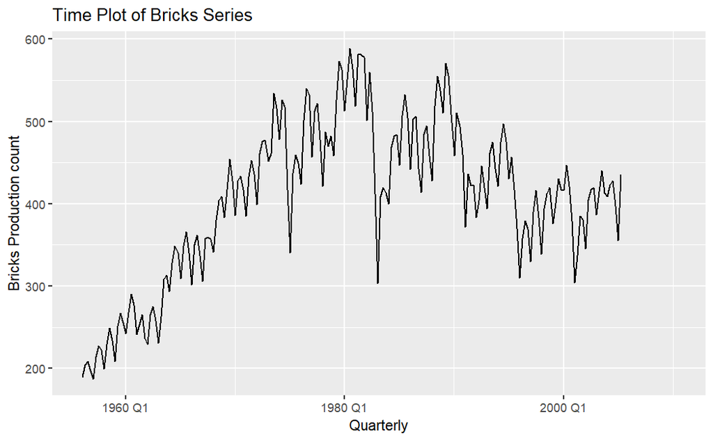

```r
autoplot(aus_production,Bricks) +
  labs(title = "Time Plot of Bricks Series",
       x = "Quarterly",
       y = "Bricks Production count")
```

## Lynx

### i

pelt is an annual tsibble with two values:

Hare: The number of Snowshoe Hare pelts traded. Lynx: The number of Canadian Lynx pelts traded.

### ii

```r
pelt %>%
  select(Lynx)
```

| Lynx | Year |
| --- | --- |
| 30090 | 1845 |
| 45150 | 1846 |
| 49150 | 1847 |
| 39520 | 1848 |
| 21230 | 1849 |
| 8420 | 1850 |
| 5560 | 1851 |
| 5080 | 1852 |
| 10170 | 1853 |
| 19600 | 1854 |

[output cut: 81 more lines]

### iii

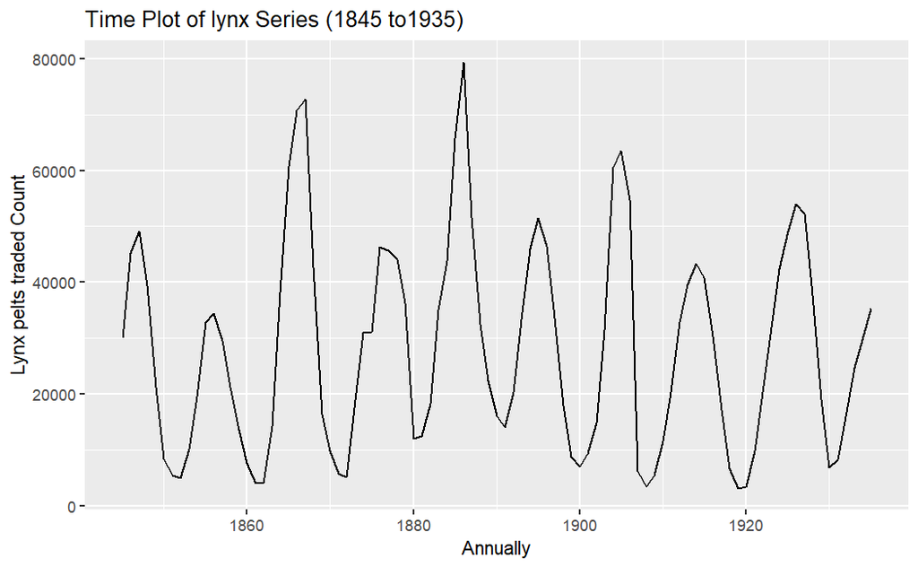

```r
autoplot(pelt,Lynx) +
  labs(title = "Time Plot of lynx Series (1845 to1935)",
       x = "Annually",
       y = "Lynx pelts traded Count")
```

## Close

### i

Details gafa_stock is a tsibble containing data on irregular trading days:

Open: The opening price for the stock. High: The stock’s highest trading price. Low: The stock’s lowest trading price. Close: The closing price for the stock. Adj_Close: The adjusted closing price for the stock. Volume: The amount of stock traded. Each stock is uniquely identified by one key:

Symbol: The ticker symbol for the stock.

### ii

```r
gafa_stock%>%
  select(Close)
```

| Close | Date | Symbol |
| --- | --- | --- |
| 79.01857 | 2014-01-02 | AAPL |
| 77.28286 | 2014-01-03 | AAPL |
| 77.70428 | 2014-01-06 | AAPL |
| 77.14857 | 2014-01-07 | AAPL |
| 77.63715 | 2014-01-08 | AAPL |
| 76.64571 | 2014-01-09 | AAPL |
| 76.13429 | 2014-01-10 | AAPL |
| 76.53286 | 2014-01-13 | AAPL |
| 78.05572 | 2014-01-14 | AAPL |
| 79.62286 | 2014-01-15 | AAPL |

[output cut: 990 more lines]

The `gafa_stock` is daily data

### iii

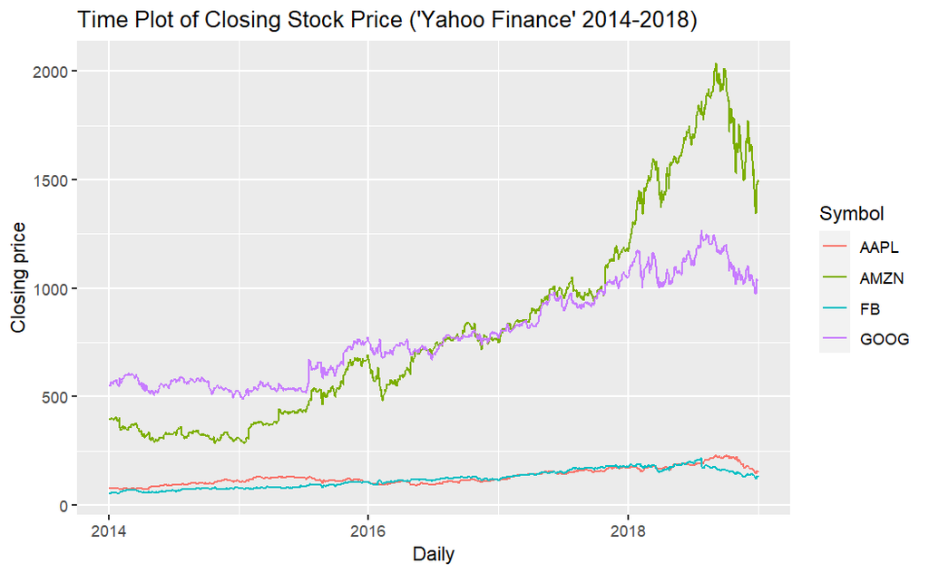

```r
autoplot(gafa_stock,Close) +
  labs(title = "Time Plot of Closing Stock Price ('Yahoo Finance' 2014-2018)",
       x = "Daily",
       y = "Closing price")
```

## Demand

### i

**Description***

`vic_elec` is a half-hourly `tsibble` with three values:

Demand: Total electricity demand in MWh. Temperature: Temperature of Melbourne (BOM site 086071). Holiday: Indicator for if that day is a public holiday.

### ii

```r
vic_elec %>%
  select(Demand)
```

| Demand | Time |
| --- | --- |
| 4382.825 | 2012-01-01 00:00:00 |
| 4263.366 | 2012-01-01 00:30:00 |
| 4048.966 | 2012-01-01 01:00:00 |
| 3877.563 | 2012-01-01 01:30:00 |
| 4036.230 | 2012-01-01 02:00:00 |
| 3865.597 | 2012-01-01 02:30:00 |
| 3694.098 | 2012-01-01 03:00:00 |
| 3561.624 | 2012-01-01 03:30:00 |
| 3433.035 | 2012-01-01 04:00:00 |
| 3359.468 | 2012-01-01 04:30:00 |

[output cut: 990 more lines]

```r
NA
```

### iii & vi

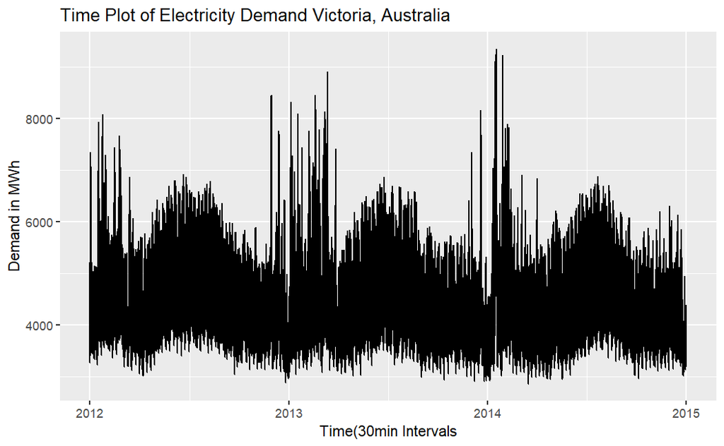

```r
autoplot(vic_elec,Demand) +
  labs(title = "Time Plot of Electricity Demand Victoria, Australia",
       x = "Time(30min Intervals",
       y = "Demand in MWh")
```

# 2.2

Use filter() to find what days corresponded to the peak closing price for each of the four stocks in gafa_stock.

```r
colnames(gafa_stock)
```

```
[1] "Symbol"    "Date"      "Open"      "High"      "Low"       "Close"     "Adj_Close" "Volume"
```

```r
 gafa_stock %>%
  group_by(Symbol) %>%
  filter(Close == max(Close))
```

| Symbol | Date | Open | High | Low | Close | Adj_Close | Volume |
| --- | --- | --- | --- | --- | --- | --- | --- |
| AAPL | 2018-10-03 | 230.05 | 233.470 | 229.78 | 232.07 | 230.2755 | 28654800 |
| AMZN | 2018-09-04 | 2026.50 | 2050.500 | 2013.00 | 2039.51 | 2039.5100 | 5721100 |
| FB | 2018-07-25 | 215.72 | 218.620 | 214.27 | 217.50 | 217.5000 | 58954200 |
| GOOG | 2018-07-26 | 1251.00 | 1269.771 | 1249.02 | 1268.33 | 1268.3300 | 2405600 |

```r
NA
```

# 2.3

Download the file `tute1.csv` from the [book website](https://bit.ly/fpptute1), open it in Excel (or some other spreadsheet application), and review its contents. You should find four columns of information. Columns B through D each contain a quarterly series, labelled Sales, AdBudget and GDP. Sales contains the quarterly sales for a small company over the period 1981-2005. AdBudget is the advertising budget and GDP is the gross domestic product. All series have been adjusted for inflation.

## a.

You can read the data into R with the following script:

```r
df_tute1 <- readr::read_csv(tute1_csv)
head(df_tute1,20)
```

| Quarter | Sales | AdBudget | GDP |
| --- | --- | --- | --- |
| 1981-03-01 | 1020.2 | 659.2 | 251.8 |
| 1981-06-01 | 889.2 | 589.0 | 290.9 |
| 1981-09-01 | 795.0 | 512.5 | 290.8 |
| 1981-12-01 | 1003.9 | 614.1 | 292.4 |
| 1982-03-01 | 1057.7 | 647.2 | 279.1 |
| 1982-06-01 | 944.4 | 602.0 | 254.0 |
| 1982-09-01 | 778.5 | 530.7 | 295.6 |
| 1982-12-01 | 932.5 | 608.4 | 271.7 |
| 1983-03-01 | 996.5 | 637.9 | 259.6 |
| 1983-06-01 | 907.7 | 582.4 | 280.5 |

[output cut: 10 more lines]

```r
NA
```

## b.

Convert the data to time series

```r
mytimeseries <- df_tute1 |>
  mutate(Quarter = yearquarter(Quarter)) |>
  as_tsibble(index = Quarter)
```

## c.

Construct time series plots of each of the three series

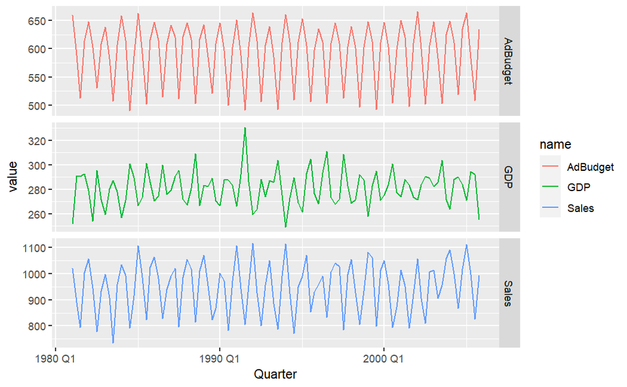

```r
mytimeseries |>
  pivot_longer(-Quarter) |>
  ggplot(aes(x = Quarter, y = value, colour = name)) +
  geom_line() +
  facet_grid(name ~ ., scales = "free_y")
```

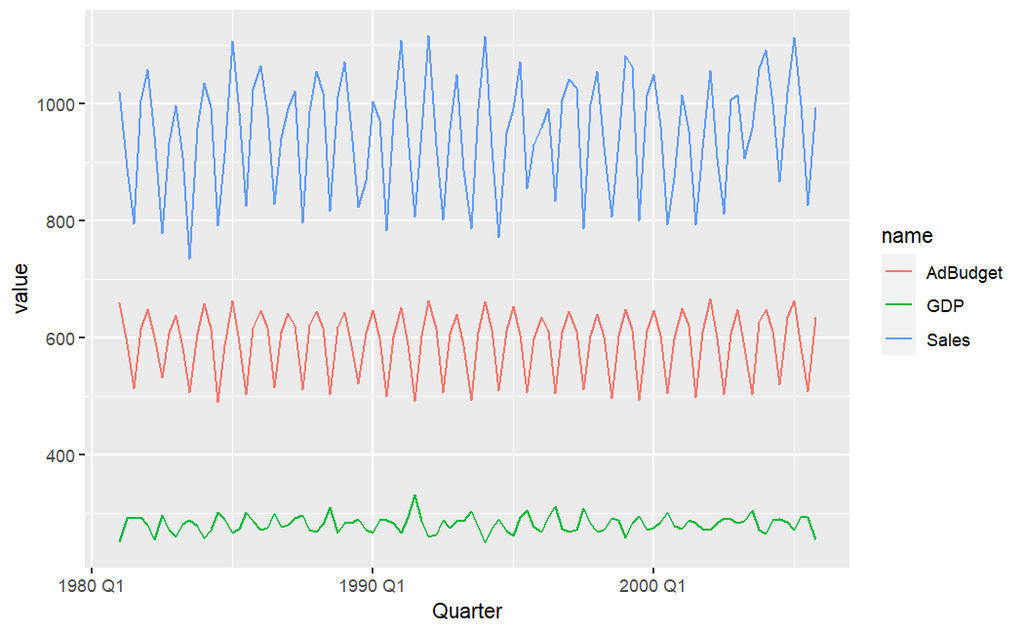

```r
mytimeseries %>%
  pivot_longer(-Quarter)%>%
  ggplot(aes(x = Quarter, y = value, colour = name)) +
  geom_line() #+
```

```r
  # facet_grid(name ~ ., scales = "free_y")
```

The plot is encompassed in one plot without the `facet_grid()` function.

# 2.4

The `USgas` package contains data on the demand for natural gas in the US.

1. Install the `USgas` package.
2. Create a `tsibble` from `us_total` with year as the index and state as the key.
3. Plot the annual natural gas consumption by state for the New England area (comprising the states of Maine, Vermont, New Hampshire, Massachusetts, Connecticut and Rhode Island).

## i

```r
str(USgas::us_total)
```

```
'data.frame':   1266 obs. of  3 variables:
 $ year : int  1997 1998 1999 2000 2001 2002 2003 2004 2005 2006 ...
 $ state: chr  "Alabama" "Alabama" "Alabama" "Alabama" ...
 $ y    : int  324158 329134 337270 353614 332693 379343 350345 382367 353156 391093 ...
```

## ii

**Example**

[Forecasting Principles & Practice: 2.1 tsibble objects](https://youtu.be/EwjvA2OcdHs?si=ytUhCrsw_IhPO1oY&t=316)

*Template*

```
    mydata <- tsibble(
        year = 2015:2019,
        y=c(123,39,78,52,110),
        index = year
    )
    mydata
```

```r
mydata <- tsibble(
  state = us_total$state,
  year = us_total$year,
  value = us_total$y,
  index = year,
  key = state
)%>%
  filter(state %in% c("Maine", "Vermont", "New Hampshire", "Massachusetts", "Connecticut", "Rhode Island"))
```

## iii

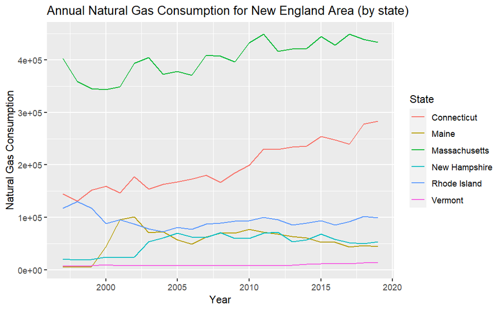

```r
ggplot(mydata, aes(x = year, y = value, color = state)) +
  geom_line() +
  labs(
    title = "Annual Natural Gas Consumption for New England Area (by state)",
    x = "Year",
    y = "Natural Gas Consumption",
    color = "State"
  )
```

# 2.5

## a.

Download `tourism.xlsx` from the [book website](https://bit.ly/fpptourism) and read it into R using `readxl::read_excel()`.

```r
PATH<-"C:/Users/Lenny/Documents/GitableGabe/Data624_Data/"
```

```r
tourism_str <- paste(PATH,"tourism.xlsx", sep = "")
df_tourism <- readxl::read_excel(tourism_str)
rm(tourism_str)
tourism
```

| Quarter | Region | State | Purpose | Trips |
| --- | --- | --- | --- | --- |
| 10227 | Adelaide | South Australia | Business | 135.0776903 |
| 10317 | Adelaide | South Australia | Business | 109.9873160 |
| 10408 | Adelaide | South Australia | Business | 166.0346866 |
| 10500 | Adelaide | South Australia | Business | 127.1604643 |
| 10592 | Adelaide | South Australia | Business | 137.4485333 |
| 10682 | Adelaide | South Australia | Business | 199.9125861 |
| 10773 | Adelaide | South Australia | Business | 169.3550898 |
| 10865 | Adelaide | South Australia | Business | 134.3579372 |
| 10957 | Adelaide | South Australia | Business | 154.0343980 |
| 11048 | Adelaide | South Australia | Business | 168.7763637 |

[output cut: 990 more lines]

## b.

Create a `tsibble` which is identical to the tourism `tsibble` from the `tsibble` package.

```r
str(df_tourism)
```

```
tibble [24,320 × 5] (S3: tbl_df/tbl/data.frame)
 $ Quarter: chr [1:24320] "1998-01-01" "1998-04-01" "1998-07-01" "1998-10-01" ...
 $ Region : chr [1:24320] "Adelaide" "Adelaide" "Adelaide" "Adelaide" ...
 $ State  : chr [1:24320] "South Australia" "South Australia" "South Australia" "South Australia" ...
 $ Purpose: chr [1:24320] "Business" "Business" "Business" "Business" ...
 $ Trips  : num [1:24320] 135 110 166 127 137 ...
```

**Example**

[Forecasting Principles & Practice: 2.1 tsibble objects](https://youtu.be/EwjvA2OcdHs?si=tg-wW4OOR3qln05l&t=661)

*Template*

```
  prison<- read::read_csv("data/prison_population.csv") %>%
            mutate(Quarter = yearquarter(date)) %>%
              select(-date) %>%
              as_tsibble(
              index = Quarter,
              key=c(state,gender,legal,indigenous)
              )
```

```r
tibble_tourism <- df_tourism %>%
  mutate(Quarter = yearquarter(Quarter)) %>%
  as_tsibble(index=Quarter,
             key = c("Region", "State", "Purpose"))

tibble_tourism
```

| Quarter | Region | State | Purpose | Trips |
| --- | --- | --- | --- | --- |
| 10227 | Adelaide | South Australia | Business | 135.0776903 |
| 10317 | Adelaide | South Australia | Business | 109.9873160 |
| 10408 | Adelaide | South Australia | Business | 166.0346866 |
| 10500 | Adelaide | South Australia | Business | 127.1604643 |
| 10592 | Adelaide | South Australia | Business | 137.4485333 |
| 10682 | Adelaide | South Australia | Business | 199.9125861 |
| 10773 | Adelaide | South Australia | Business | 169.3550898 |
| 10865 | Adelaide | South Australia | Business | 134.3579372 |
| 10957 | Adelaide | South Australia | Business | 154.0343980 |
| 11048 | Adelaide | South Australia | Business | 168.7763637 |

[output cut: 990 more lines]

```r
NA
```

## c.

Find what combination of Region and Purpose had the maximum number of overnight trips on average.

```r
tibble_tourism %>%
  group_by(Region,Purpose)%>%
  summarize(TripsAvg = mean(Trips))%>%
  filter(TripsAvg == max(TripsAvg))%>%
  arrange(desc(TripsAvg))
```

| Region | Purpose | Quarter | TripsAvg |
| --- | --- | --- | --- |
| Melbourne | Visiting | 17440 | 985.27840 |
| Sydney | Business | 11596 | 948.12936 |
| South Coast | Holiday | 10227 | 914.77283 |
| North Coast NSW | Holiday | 16801 | 905.84500 |
| Brisbane | Visiting | 17075 | 796.30206 |
| Gold Coast | Holiday | 11688 | 711.03724 |
| Sunshine Coast | Holiday | 12784 | 617.47597 |
| Australia's South West | Holiday | 16801 | 612.08986 |
| Great Ocean Road | Holiday | 10227 | 548.41108 |
| Experience Perth | Visiting | 16801 | 538.26505 |

[output cut: 66 more lines]

```r
NA
```

## d.

Create a new `tsibble` which combines the Purposes and Regions, and just has total trips by State.

```r
tibble_tourism_v2 <- tibble_tourism %>%
  group_by(State)%>%
  summarize(Total=sum(Trips))

tibble_tourism_v2
```

| State | Quarter | Total |
| --- | --- | --- |
| ACT | 10227 | 551.0019 |
| ACT | 10317 | 416.0256 |
| ACT | 10408 | 436.0290 |
| ACT | 10500 | 449.7984 |
| ACT | 10592 | 378.5728 |
| ACT | 10682 | 558.1781 |
| ACT | 10773 | 448.9012 |
| ACT | 10865 | 594.8254 |
| ACT | 10957 | 599.6685 |
| ACT | 11048 | 557.1351 |

[output cut: 630 more lines]

# 2.8

Use the following graphics functions: `autoplot()`, `gg_season()`, `gg_subseries()`, `gg_lag()`, `ACF()` and explore features from the following time series: “Total Private” `Employed` from `us_employment`, `Bricks` from `aus_production`, `Hare` from `pelt`, “H02” `Cost` from `PBS`, and `Barrels` from `us_gasoline`.

1. Can you spot any seasonality, cyclicity and trend?
2. What do you learn about the series?
3. What can you say about the seasonal patterns?
4. Can you identify any unusual years?

## Total Private

**Example**

```
  vic_elec |> gg_season(Demand, period = "day") +
    theme(legend.position = "none") +
    labs(y="MWh", title="Electricity demand: Victoria")
```

```r
us_employment
```

| Month | Series_ID | Title | Employed |
| --- | --- | --- | --- |
| -11323 | CEU0500000001 | Total Private | 25338 |
| -11292 | CEU0500000001 | Total Private | 25447 |
| -11264 | CEU0500000001 | Total Private | 25833 |
| -11233 | CEU0500000001 | Total Private | 25801 |
| -11203 | CEU0500000001 | Total Private | 26113 |
| -11172 | CEU0500000001 | Total Private | 26485 |
| -11142 | CEU0500000001 | Total Private | 26481 |
| -11111 | CEU0500000001 | Total Private | 26848 |
| -11080 | CEU0500000001 | Total Private | 27468 |
| -11050 | CEU0500000001 | Total Private | 27830 |

[output cut: 990 more lines]

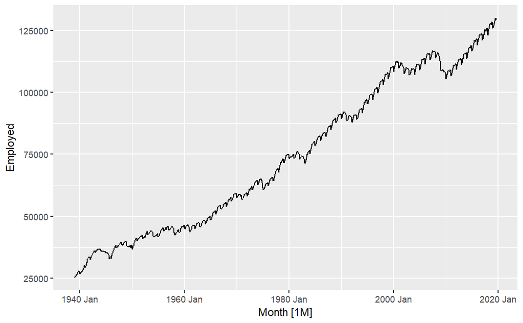

```r
us_employment%>%
  filter(Title=="Total Private")%>%
  autoplot(Employed,period="month")
```

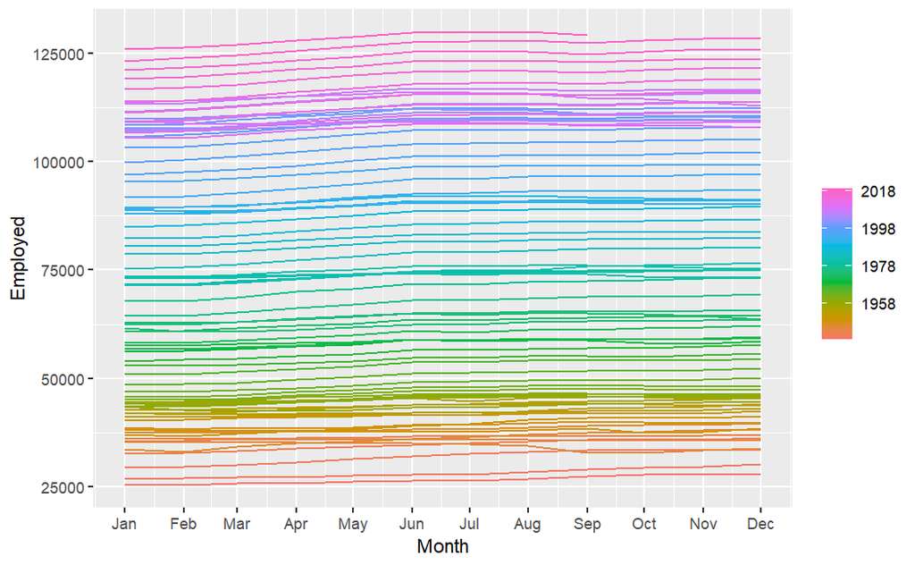

```r
us_employment%>%
  filter(Title=="Total Private")%>%
  gg_season(Employed, polar = FALSE)
```

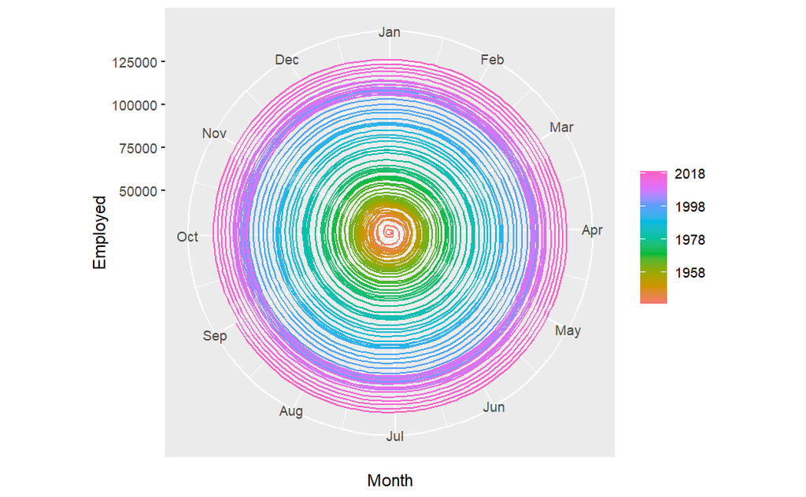

```r
us_employment%>%
  filter(Title=="Total Private")%>%
  gg_season(Employed, polar = TRUE)
```

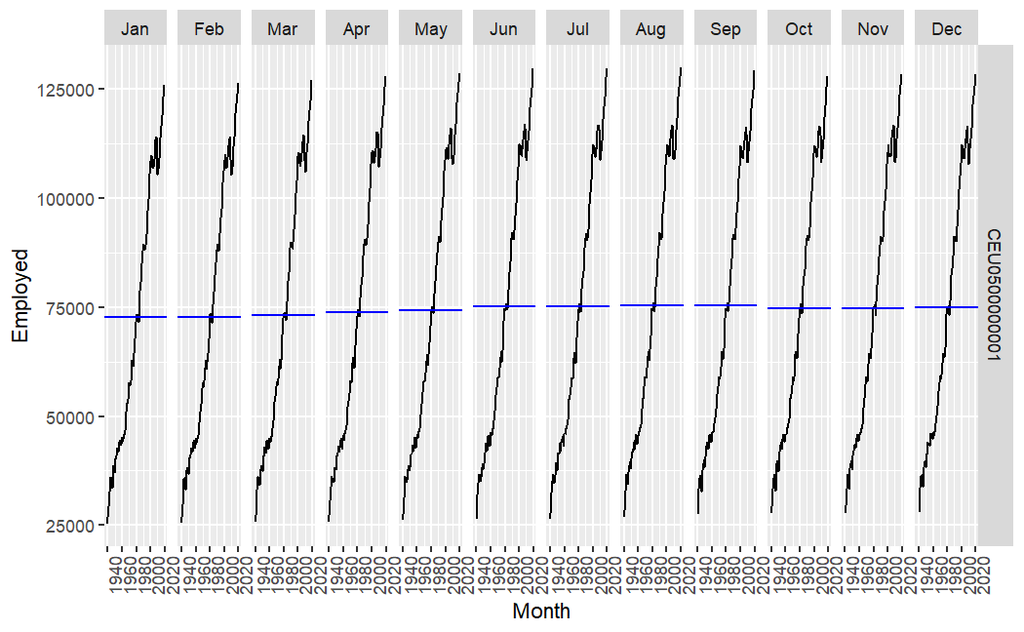

```r
us_employment%>%
  filter(Title=="Total Private")%>%
  gg_subseries(Employed)
```

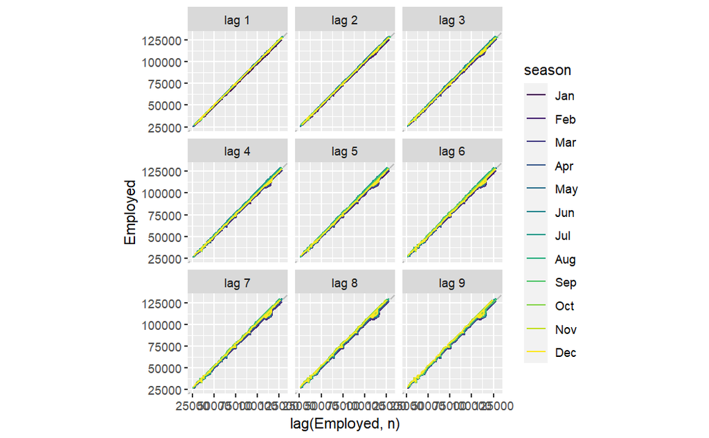

```r
us_employment%>%
  filter(Title=="Total Private")%>%
  gg_lag(Employed)
```

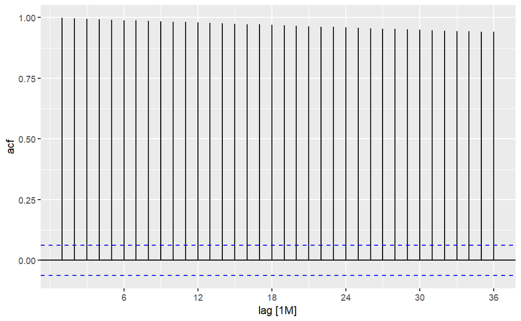

```r
us_employment%>%
  filter(Title=="Total Private")%>%
  ACF(us_employment$Employed)%>%
  autoplot()
```

### i

There is a clear upwards trend in small increments for the data.

### iii

No Seasonality is noted indicating there is not particular season with an affect on employment positive or negative.

### iv

A small dip around 2010 which I believe aligns with the recession.

## Bricks

| Quarter | Beer | Tobacco | Bricks | Cement | Electricity | Gas |
| --- | --- | --- | --- | --- | --- | --- |
| -5114 | 284 | 5225 | 189 | 465 | 3923 | 5 |
| -5023 | 213 | 5178 | 204 | 532 | 4436 | 6 |
| -4932 | 227 | 5297 | 208 | 561 | 4806 | 7 |
| -4840 | 308 | 5681 | 197 | 570 | 4418 | 6 |
| -4748 | 262 | 5577 | 187 | 529 | 4339 | 5 |
| -4658 | 228 | 5651 | 214 | 604 | 4811 | 7 |
| -4567 | 236 | 5317 | 227 | 603 | 5259 | 7 |
| -4475 | 320 | 6152 | 222 | 582 | 4735 | 6 |
| -4383 | 272 | 5758 | 199 | 554 | 4608 | 5 |
| -4293 | 233 | 5641 | 229 | 620 | 5196 | 7 |

[output cut: 208 more lines]

```
Plot variable not specified, automatically selected `.vars = Bricks`Warning: Ignoring unknown parameters: `period`
```

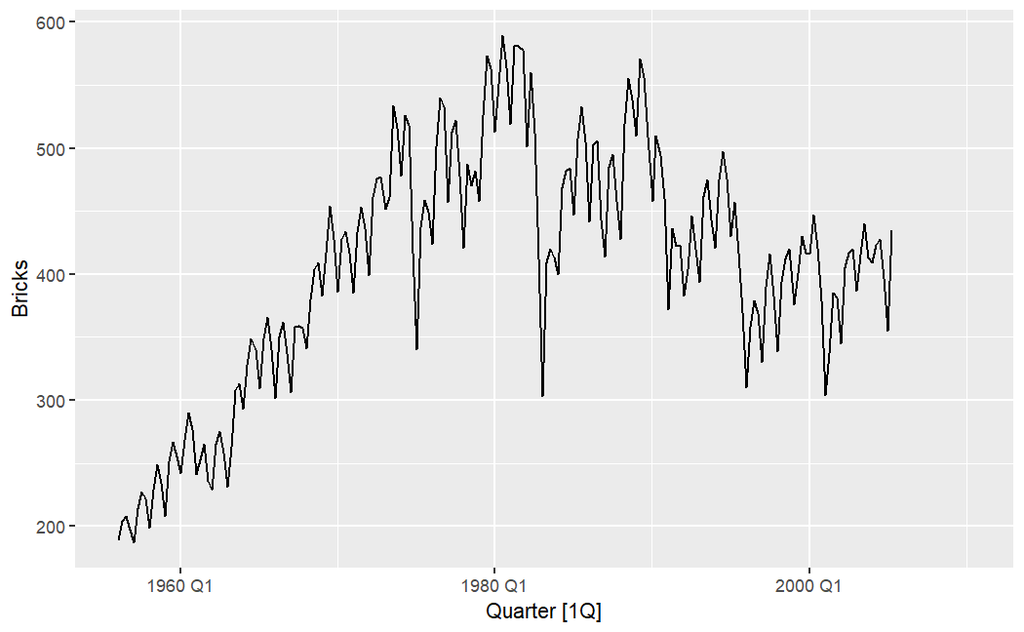

```r
aus_production%>%
  select(Bricks)%>%
  autoplot(period="quarter")
```

```
Plot variable not specified, automatically selected `y = Bricks`
```

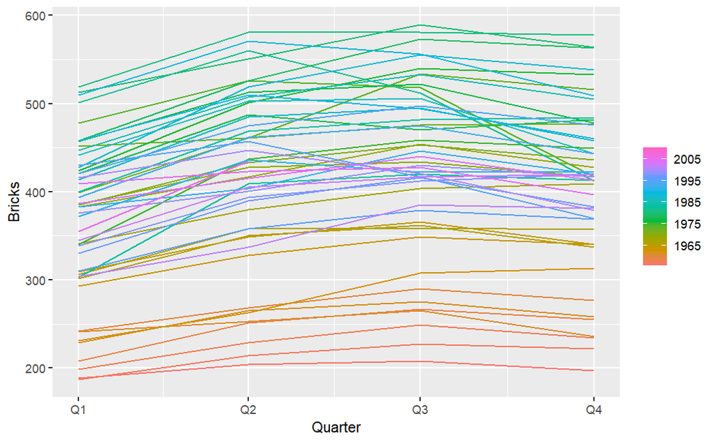

```r
aus_production%>%
  select(Bricks)%>%
  gg_season( polar = FALSE)
```

```
Plot variable not specified, automatically selected `y = Bricks`
```

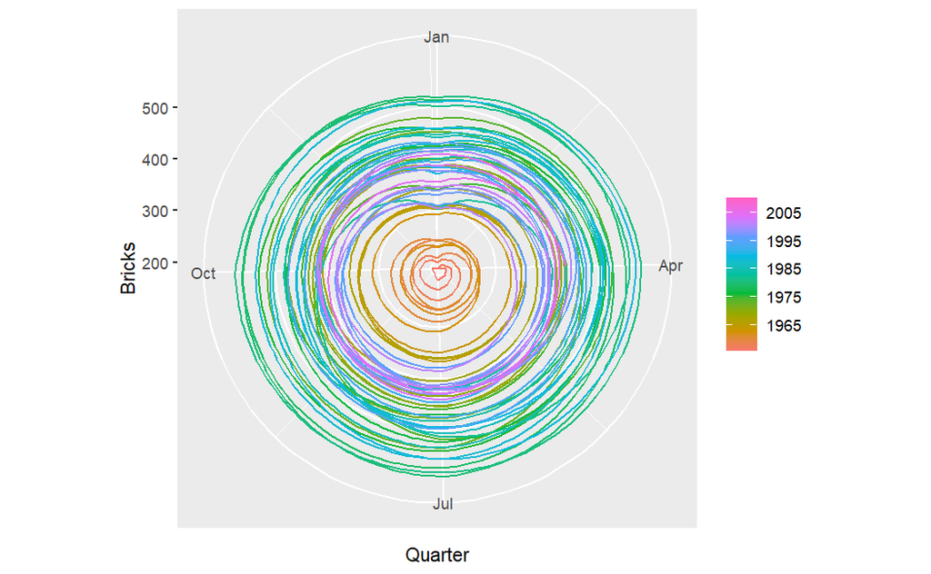

```r
aus_production%>%
  select(Bricks)%>%
  gg_season( polar = TRUE)
```

```
Plot variable not specified, automatically selected `y = Bricks`
```

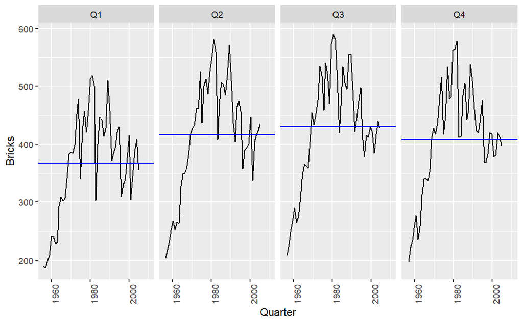

```r
aus_production%>%
  select(Bricks)%>%
  gg_subseries()
```

```
Plot variable not specified, automatically selected `y = Bricks`Warning: Removed 20 rows containing missing values (gg_lag).
```

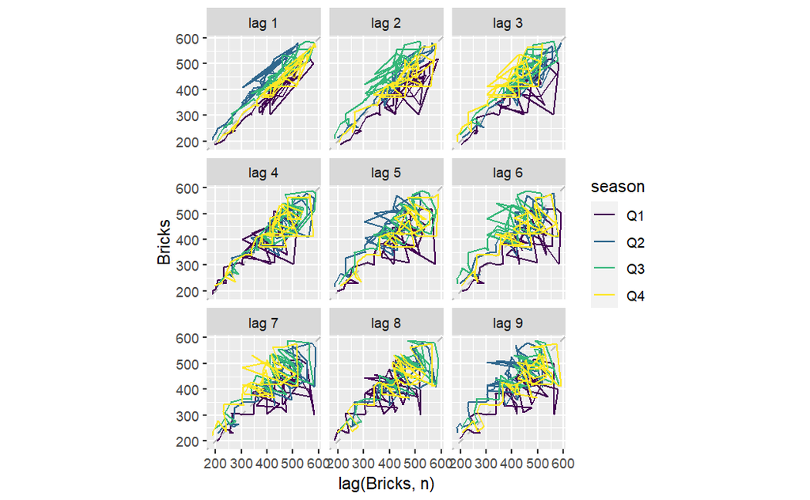

```r
aus_production%>%
  select(Bricks)%>%
  gg_lag()
```

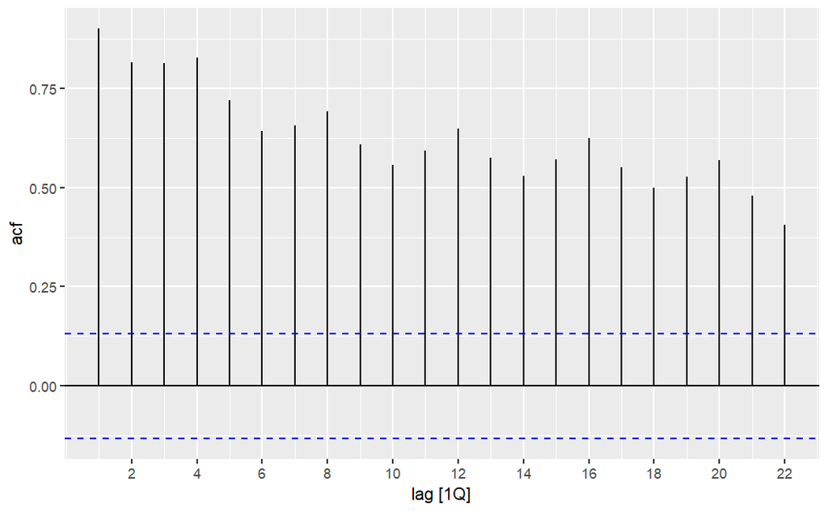

```r
aus_production%>%
  select(Bricks)%>%
  ACF(aus_production$Bricks)%>%
  autoplot()
```

### i

There is lots of cyclicity with frequent spikes and dips, but it does not appear to be consistent to a time period.There is a positive upward trend in the long term.

### ii

The data being broken down to Quarters my influence how well we can assess the potential seasonality. As is, there does seem to be one.

### iii

There seems to be some seasonality as far as Q1 and Q3 is concerned.

### iv

The early 1980s has a significant dip so I would be curious to understand what may have cause this.

## Hare

| Year | Hare | Lynx |
| --- | --- | --- |
| 1845 | 19580 | 30090 |
| 1846 | 19600 | 45150 |
| 1847 | 19610 | 49150 |
| 1848 | 11990 | 39520 |
| 1849 | 28040 | 21230 |
| 1850 | 58000 | 8420 |
| 1851 | 74600 | 5560 |
| 1852 | 75090 | 5080 |
| 1853 | 88480 | 10170 |
| 1854 | 61280 | 19600 |

[output cut: 81 more lines]

```
Plot variable not specified, automatically selected `.vars = Hare`Warning: Ignoring unknown parameters: `period`
```

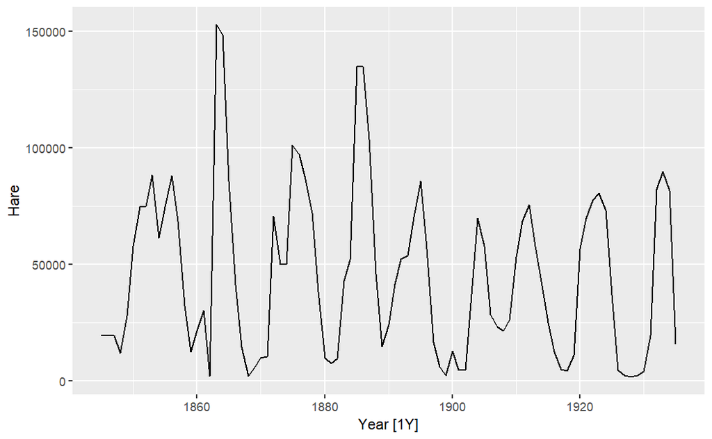

```r
pelt%>%
  select(Hare)%>%
  autoplot(period="year")
```

```
Plot variable not specified, automatically selected `y = Hare`
```

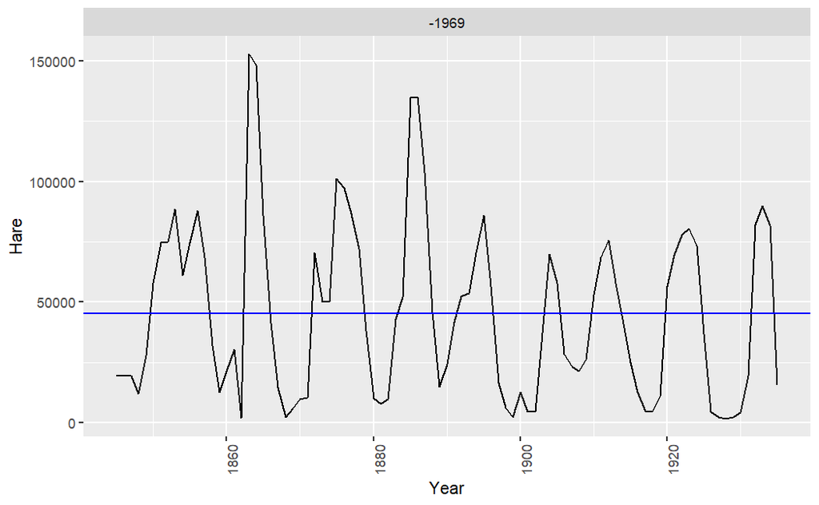

```r
#Not possible
# pelt%>%
#   select(Hare)%>%
#   gg_season( polar = FALSE)
#
# pelt%>%
#   select(Hare)%>%
#   gg_season( polar = TRUE)

pelt%>%
  select(Hare)%>%
  gg_subseries()
```

```
Plot variable not specified, automatically selected `y = Hare`
```

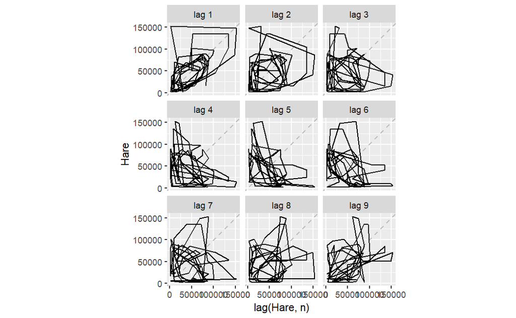

```r
pelt%>%
  select(Hare)%>%
  gg_lag()
```

```
Response variable not specified, automatically selected `var = Hare`
```

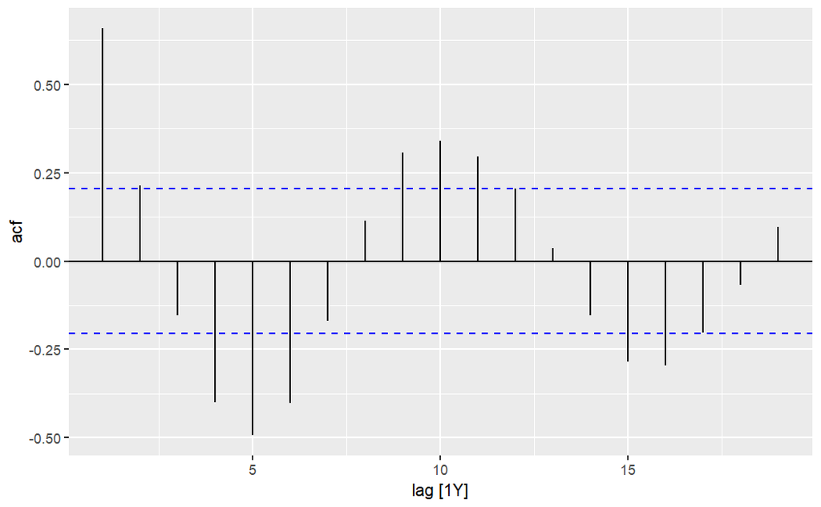

```r
pelt%>%
  select(Hare)%>%
  ACF()%>%
  autoplot()
```

### i

The data is definitely cyclical but its not possible to teal seasonality since its at a annual basis.

### iii

Again no seasonality

### iv

Im curious what caused the peak in the early 1860s

## Cost

| Month | Concession | Type | ATC1 | ATC1_desc | ATC2 | ATC2_desc | Scripts | Cost |
| --- | --- | --- | --- | --- | --- | --- | --- | --- |
| 7851 | Concessional | Co-payments | A | Alimentary tract and metabolism | A01 | STOMATOLOGICAL PREPARATIONS | 18228 | 67877.00 |
| 7882 | Concessional | Co-payments | A | Alimentary tract and metabolism | A01 | STOMATOLOGICAL PREPARATIONS | 15327 | 57011.00 |
| 7913 | Concessional | Co-payments | A | Alimentary tract and metabolism | A01 | STOMATOLOGICAL PREPARATIONS | 14775 | 55020.00 |
| 7943 | Concessional | Co-payments | A | Alimentary tract and metabolism | A01 | STOMATOLOGICAL PREPARATIONS | 15380 | 57222.00 |
| 7974 | Concessional | Co-payments | A | Alimentary tract and metabolism | A01 | STOMATOLOGICAL PREPARATIONS | 14371 | 52120.00 |
| 8004 | Concessional | Co-payments | A | Alimentary tract and metabolism | A01 | STOMATOLOGICAL PREPARATIONS | 15028 | 54299.00 |
| 8035 | Concessional | Co-payments | A | Alimentary tract and metabolism | A01 | STOMATOLOGICAL PREPARATIONS | 11040 | 39753.00 |
| 8066 | Concessional | Co-payments | A | Alimentary tract and metabolism | A01 | STOMATOLOGICAL PREPARATIONS | 15165 | 54405.00 |
| 8095 | Concessional | Co-payments | A | Alimentary tract and metabolism | A01 | STOMATOLOGICAL PREPARATIONS | 16898 | 61108.00 |
| 8126 | Concessional | Co-payments | A | Alimentary tract and metabolism | A01 | STOMATOLOGICAL PREPARATIONS | 18141 | 65356.00 |

[output cut: 990 more lines]

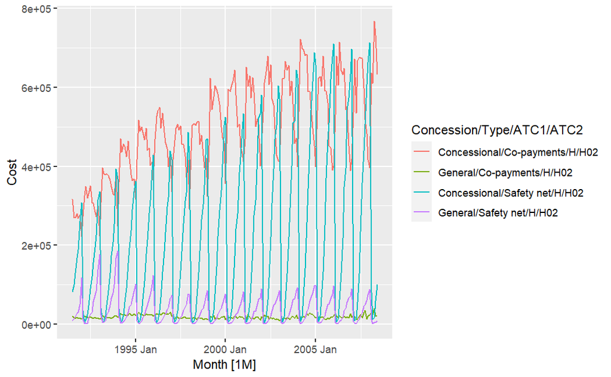

```r
PBS%>%
  filter(ATC2=="H02")%>%
  autoplot(Cost)
```

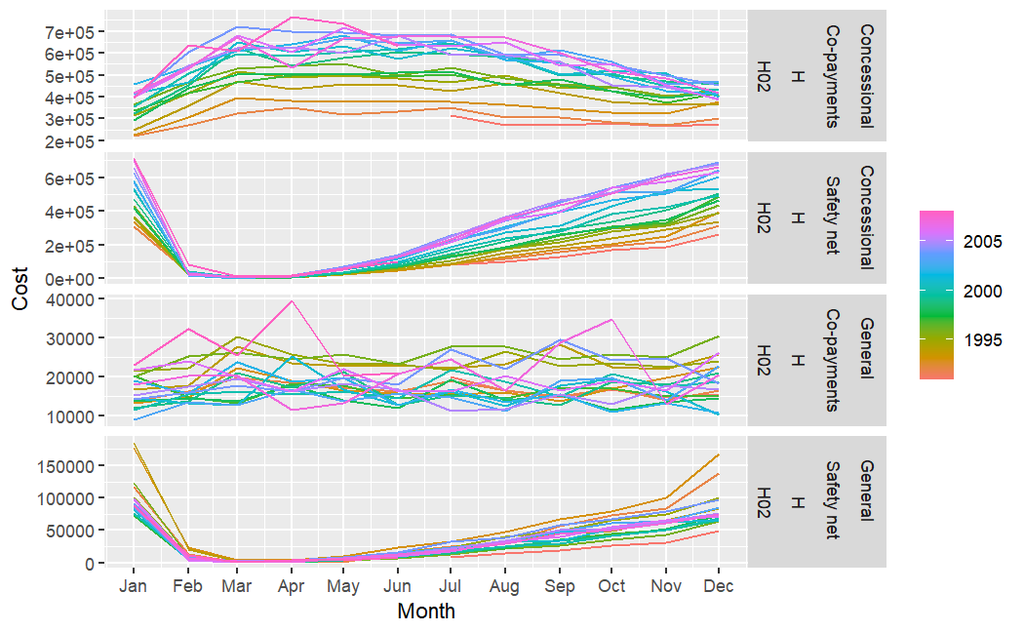

```r
PBS %>%
  filter(ATC2 == "H02") %>%
  gg_season(Cost, polar = FALSE)
```

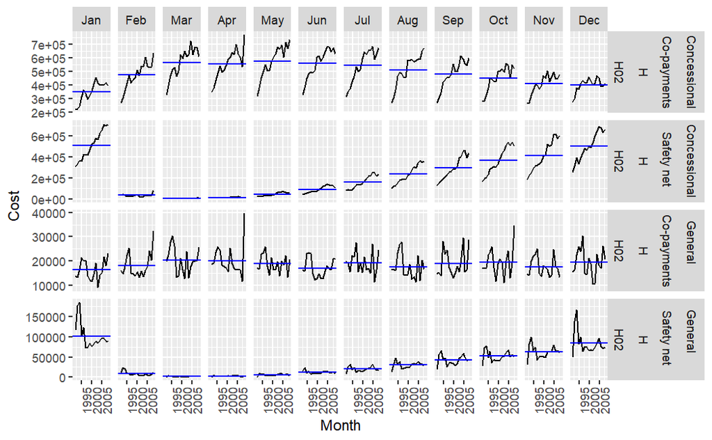

```r
PBS %>%
  filter(ATC2 == "H02") %>%
  gg_subseries(Cost)
```

```r
# PBS %>%
#   filter(ATC2 == "H02") %>%
#   gg_lag(Cost)
```

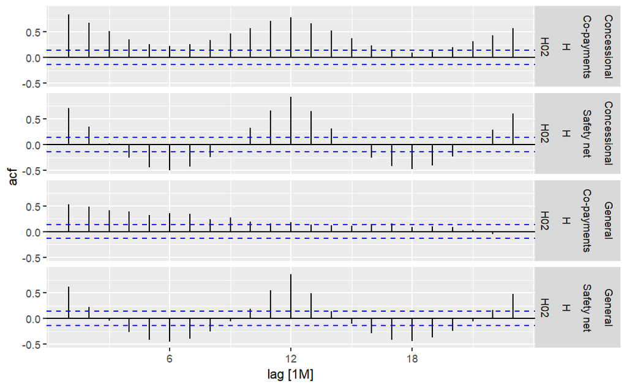

```r
PBS %>%
  filter(ATC2 == "H02") %>%
  ACF(Cost)%>%
  autoplot()
```

### i

The data is hard to interpret but it appears to trend upwards with cyclicity and seasonality. ### ii

the data is very volatile but spikes mainly end of year it appears.

### iii

The seasonality is at the end of the year.

### iv

No year stands out, outside of the latest year having the highest cost.

## Barrels

| Week | Barrels |
| --- | --- |
| 7704 | 6.621 |
| 7711 | 6.433 |
| 7718 | 6.582 |
| 7725 | 7.224 |
| 7732 | 6.875 |
| 7739 | 6.947 |
| 7746 | 7.328 |
| 7753 | 6.777 |
| 7760 | 7.503 |
| 7767 | 6.916 |

[output cut: 990 more lines]

```
Plot variable not specified, automatically selected `.vars = Barrels`
```

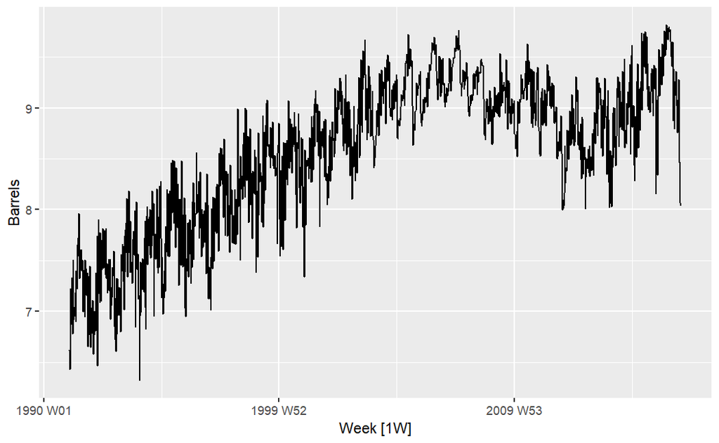

```r
us_gasoline%>%
  select(Barrels)%>%
  autoplot()
```

```
Plot variable not specified, automatically selected `y = Barrels`
```

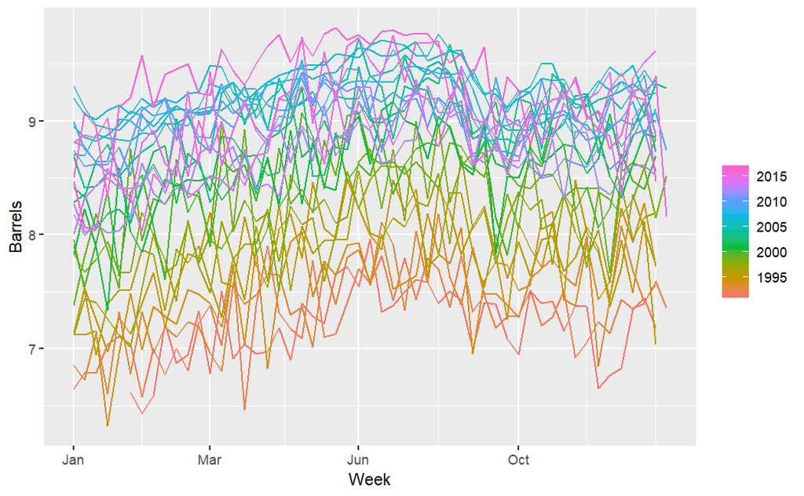

```r
us_gasoline%>%
  select(Barrels)%>%
  gg_season(polar = FALSE)
```

```
Plot variable not specified, automatically selected `y = Barrels`
```

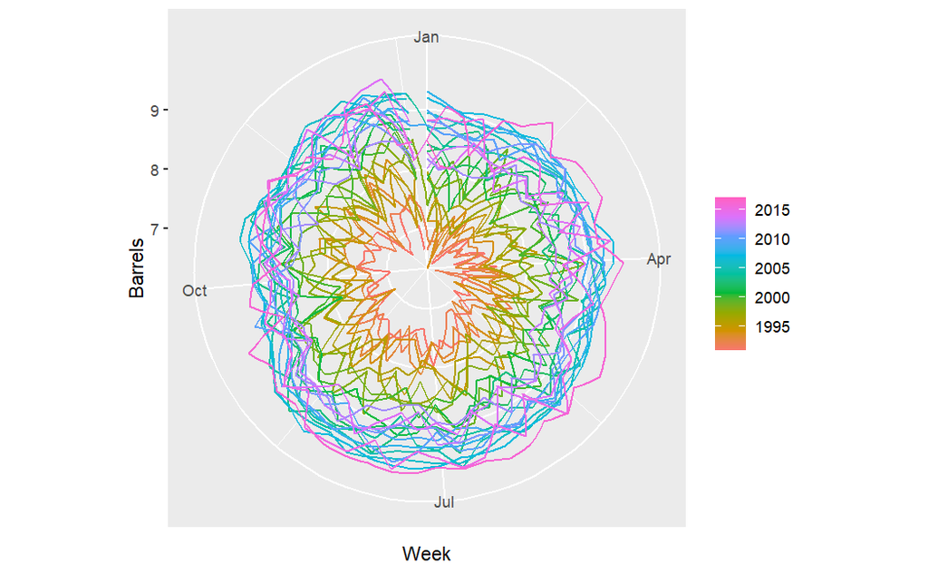

```r
us_gasoline%>%
  select(Barrels)%>%
  gg_season( polar = TRUE)
```